# Visualizing FordGoBike Data

## (2017)

[output not shown]

# Preliminary Wrangling

```python
#all package
import numpy as np
import pandas as pd
import matplotlib.pyplot as plt
%matplotlib inline
import seaborn as sb
import calendar
import datetime
```

**Loading in the dataset**

```python
#load data
df=pd.read_csv('2017-fordgobike-tripdata.csv')
```

```python
df.head(2)
```

|  | duration_sec | start_time | end_time | start_station_id | start_station_name | start_station_latitude | start_station_longitude | end_station_id | end_station_name | end_station_latitude | end_station_longitude | bike_id | user_type |
| --- | --- | --- | --- | --- | --- | --- | --- | --- | --- | --- | --- | --- | --- |
| 0 | 80110 | 2017-12-31 16:57:39.6540 | 2018-01-01 15:12:50.2450 | 74 | Laguna St at Hayes St | 37.776435 | -122.426244 | 43 | San Francisco Public Library (Grove St at Hyde... | 37.778768 | -122.415929 | 96 | Customer |
| 1 | 78800 | 2017-12-31 15:56:34.8420 | 2018-01-01 13:49:55.6170 | 284 | Yerba Buena Center for the Arts (Howard St at ... | 37.784872 | -122.400876 | 96 | Dolores St at 15th St | 37.766210 | -122.426614 | 88 | Customer |

```python
# information of data
df.info()
```

```
<class 'pandas.core.frame.DataFrame'>
RangeIndex: 519700 entries, 0 to 519699
Data columns (total 13 columns):
duration_sec               519700 non-null int64
start_time                 519700 non-null object
end_time                   519700 non-null object
start_station_id           519700 non-null int64
start_station_name         519700 non-null object
start_station_latitude     519700 non-null float64
start_station_longitude    519700 non-null float64
end_station_id             519700 non-null int64
end_station_name           519700 non-null object
end_station_latitude       519700 non-null float64
end_station_longitude      519700 non-null float64
bike_id                    519700 non-null int64
user_type                  519700 non-null object
dtypes: float64(4), int64(4), object(5)
memory usage: 51.5+ MB
```

```python
# checking duplicate
df.duplicated().sum()
```

```
0
```

```python
df.shape
```

```
(519700, 13)
```

# Cleaning

```
we need to clean our data like:-
      .Starting and ending times to the timestamp format
      .Bike ID, start station ID, and end station ID to object format
      .User type to category format
```

```python
#null values
df.isna().sum()
```

```
duration_sec               0
start_time                 0
end_time                   0
start_station_id           0
start_station_name         0
start_station_latitude     0
start_station_longitude    0
end_station_id             0
end_station_name           0
end_station_latitude       0
end_station_longitude      0
bike_id                    0
user_type                  0
dtype: int64
```

```python
#making the copy of data so the original data remains unchanged
df_cleaned=df.copy()
```

```python
# Changing the format to datetime
df_cleaned.start_time = pd.to_datetime(df_cleaned.start_time)
df_cleaned.end_time = pd.to_datetime(df_cleaned.end_time)
```

```python
# User type to category format
df_cleaned['user_type ']=df_cleaned.user_type.astype('category')
```

```python
#Bike ID, start station ID, and end station ID to object format
df_cleaned['bike_id ']=df_cleaned.bike_id.astype(str)
df_cleaned['start_station_id  ']=df_cleaned.start_station_id .astype(str)
df_cleaned['end_station_id ']=df_cleaned.end_station_id.astype(str)
```

# Test

```python
df_cleaned.info()
```

```
<class 'pandas.core.frame.DataFrame'>
RangeIndex: 519700 entries, 0 to 519699
Data columns (total 17 columns):
duration_sec               519700 non-null int64
start_time                 519700 non-null datetime64[ns]
end_time                   519700 non-null datetime64[ns]
start_station_id           519700 non-null int64
start_station_name         519700 non-null object
start_station_latitude     519700 non-null float64
start_station_longitude    519700 non-null float64
end_station_id             519700 non-null int64
end_station_name           519700 non-null object
end_station_latitude       519700 non-null float64
end_station_longitude      519700 non-null float64
bike_id                    519700 non-null int64
user_type                  519700 non-null object
user_type                  519700 non-null category
bike_id                    519700 non-null object
start_station_id           519700 non-null object
end_station_id             519700 non-null object
dtypes: category(1), datetime64[ns](2), float64(4), int64(4), object(6)
memory usage: 63.9+ MB
```

## Define

**Add new coloumns like month weekday**

```python
# Start time month (January - December) and (1-12)
# a. month of the year
df_cleaned['start_time'] = pd.to_datetime(df_cleaned['start_time'])
df_cleaned['start_month_num'] = df_cleaned['start_time'].apply(lambda time: time.month)
df_cleaned['start_month_char'] = df_cleaned['start_month_num'].apply(lambda x: calendar.month_abbr[x])
```

```python
# Start time weekday
df_cleaned['start_time_weekday'] = df_cleaned['start_time'].dt.strftime('%a')
```

```python
# Start and end time hour
df_cleaned['start_time_hour'] = df_cleaned['start_time'].dt.hour
df_cleaned['end_time_hour'] = df_cleaned['end_time'].dt.hour
```

```python
#adding duration minute
df_cleaned['duration_min'] = df_cleaned['duration_sec']/60
```

## Test

```python
df_cleaned.head()
```

|  | duration_sec | start_time | end_time | start_station_id | start_station_name | start_station_latitude | start_station_longitude | end_station_id | end_station_name | end_station_latitude | ... | user_type | bike_id | start_station_id | end_station_id | start_month_num | start_month_char | start_time_weekday | start_time_hour | end_time_hour | duration_min |
| --- | --- | --- | --- | --- | --- | --- | --- | --- | --- | --- | --- | --- | --- | --- | --- | --- | --- | --- | --- | --- | --- |
| 0 | 80110 | 2017-12-31 16:57:39.654 | 2018-01-01 15:12:50.245 | 74 | Laguna St at Hayes St | 37.776435 | -122.426244 | 43 | San Francisco Public Library (Grove St at Hyde... | 37.778768 | ... | Customer | 96 | 74 | 43 | 12 | Dec | Sun | 16 | 15 | 1335.166667 |
| 1 | 78800 | 2017-12-31 15:56:34.842 | 2018-01-01 13:49:55.617 | 284 | Yerba Buena Center for the Arts (Howard St at ... | 37.784872 | -122.400876 | 96 | Dolores St at 15th St | 37.766210 | ... | Customer | 88 | 284 | 96 | 12 | Dec | Sun | 15 | 13 | 1313.333333 |
| 2 | 45768 | 2017-12-31 22:45:48.411 | 2018-01-01 11:28:36.883 | 245 | Downtown Berkeley BART | 37.870348 | -122.267764 | 245 | Downtown Berkeley BART | 37.870348 | ... | Customer | 1094 | 245 | 245 | 12 | Dec | Sun | 22 | 11 | 762.800000 |
| 3 | 62172 | 2017-12-31 17:31:10.636 | 2018-01-01 10:47:23.531 | 60 | 8th St at Ringold St | 37.774520 | -122.409449 | 5 | Powell St BART Station (Market St at 5th St) | 37.783899 | ... | Customer | 2831 | 60 | 5 | 12 | Dec | Sun | 17 | 10 | 1036.200000 |
| 4 | 43603 | 2017-12-31 14:23:14.001 | 2018-01-01 02:29:57.571 | 239 | Bancroft Way at Telegraph Ave | 37.868813 | -122.258764 | 247 | Fulton St at Bancroft Way | 37.867789 | ... | Subscriber | 3167 | 239 | 247 | 12 | Dec | Sun | 14 | 2 | 726.716667 |

5 rows × 23 columns

```python
df_cleaned.info(null_counts = True)
```

```
<class 'pandas.core.frame.DataFrame'>
RangeIndex: 519700 entries, 0 to 519699
Data columns (total 23 columns):
duration_sec               519700 non-null int64
start_time                 519700 non-null datetime64[ns]
end_time                   519700 non-null datetime64[ns]
start_station_id           519700 non-null int64
start_station_name         519700 non-null object
start_station_latitude     519700 non-null float64
start_station_longitude    519700 non-null float64
end_station_id             519700 non-null int64
end_station_name           519700 non-null object
end_station_latitude       519700 non-null float64
end_station_longitude      519700 non-null float64
bike_id                    519700 non-null int64
user_type                  519700 non-null object
user_type                  519700 non-null category
bike_id                    519700 non-null object
start_station_id           519700 non-null object
end_station_id             519700 non-null object
start_month_num            519700 non-null int64
start_month_char           519700 non-null object
start_time_weekday         519700 non-null object
start_time_hour            519700 non-null int64
end_time_hour              519700 non-null int64
duration_min               519700 non-null float64
dtypes: category(1), datetime64[ns](2), float64(5), int64(7), object(8)
memory usage: 87.7+ MB
```

```python
df_cleaned.sample(5)
```

|  | duration_sec | start_time | end_time | start_station_id | start_station_name | start_station_latitude | start_station_longitude | end_station_id | end_station_name | end_station_latitude | ... | user_type | bike_id | start_station_id | end_station_id | start_month_num | start_month_char | start_time_weekday | start_time_hour | end_time_hour | duration_min |
| --- | --- | --- | --- | --- | --- | --- | --- | --- | --- | --- | --- | --- | --- | --- | --- | --- | --- | --- | --- | --- | --- |
| 201324 | 417 | 2017-10-26 11:47:08.452 | 2017-10-26 11:54:06.362 | 5 | Powell St BART Station (Market St at 5th St) | 37.783899 | -122.408445 | 76 | McCoppin St at Valencia St | 37.771662 | ... | Subscriber | 204 | 5 | 76 | 10 | Oct | Thu | 11 | 11 | 6.950000 |
| 239440 | 564 | 2017-10-16 09:13:36.462 | 2017-10-16 09:23:01.306 | 67 | San Francisco Caltrain Station 2 (Townsend St... | 37.776639 | -122.395526 | 58 | Market St at 10th St | 37.776619 | ... | Subscriber | 1772 | 67 | 58 | 10 | Oct | Mon | 9 | 9 | 9.400000 |
| 41665 | 249 | 2017-12-13 17:34:33.784 | 2017-12-13 17:38:43.754 | 314 | Santa Clara St at Almaden Blvd | 37.333988 | -121.894902 | 312 | San Jose Diridon Station | 37.329732 | ... | Subscriber | 2250 | 314 | 312 | 12 | Dec | Wed | 17 | 17 | 4.150000 |
| 397261 | 744 | 2017-08-29 19:02:50.803 | 2017-08-29 19:15:15.122 | 178 | Broadway at 30th St | 37.819381 | -122.261928 | 182 | 19th Street BART Station | 37.809013 | ... | Customer | 1590 | 178 | 182 | 8 | Aug | Tue | 19 | 19 | 12.400000 |
| 44574 | 425 | 2017-12-13 06:59:25.236 | 2017-12-13 07:06:30.370 | 115 | Jackson Playground | 37.765026 | -122.398773 | 130 | 22nd St Caltrain Station | 37.757369 | ... | Subscriber | 313 | 115 | 130 | 12 | Dec | Wed | 6 | 7 | 7.083333 |

5 rows × 23 columns

**Save the cleaned data set to a new file**

```python
df_cleaned.to_csv('fordgo_cleaned.csv', index = False)
```

## What is the structure of your dataset?

The column header descriptions are as follows:

```
  Trip Duration:-
        .Start Time and Date

        .End Time and Date

  Start Station ID:-
        .Start Station Name

       .Start Station Latitude

       .Start Station Longitude

  End Station ID:-

       .End Station Name

       .End Station Latitude

      .End Station Longitude

      .Bike ID

  .User Type
```

what i added:

```
    .Start Time Month

    .Start Time Month Number

    .Start Time Day of the Week

    .Start Time Hour

    .duration minute
```

## What are the main feature(s) of interest in your dataset?

I am most interested start time/location and end time/location

# Univariate Exploration

```python
# Before we visualize our data, let's see what kind of numbers we're looking at
df_cleaned.start_month_char.describe()
```

```
count     519700
unique         7
top          Oct
freq      108937
Name: start_month_char, dtype: object
```

## Ford GoBike Usage by Month

October is the most popular month, with september as the second most popular, and November as the third most popular months to use the bike system.

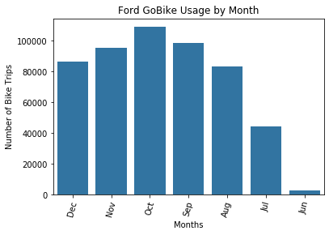

```python
# Monthly usage of the Ford Go Bike system

base_color=sb.color_palette()[0]

sb.countplot(data=df_cleaned,x='start_month_char',color =base_color);
plt.xlabel("Months")
plt.ylabel("Number of Bike Trips")
plt.title('Ford GoBike Usage by Month')
plt.xticks(rotation=75);
```

**observation1** October is the most popular month, with september as the second most popular, and November as the third most popular months to use the bike system.

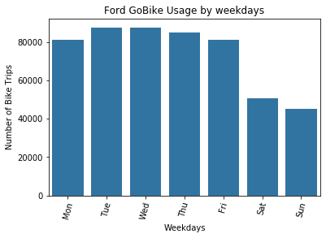

```python
## Weekday usage of the Ford Go bike system

weekday = ['Mon', 'Tue', 'Wed', 'Thu', 'Fri', 'Sat', 'Sun']
base_color=sb.color_palette()[0]

sb.countplot(data=df_cleaned,x='start_time_weekday',color =base_color,order=weekday);
plt.xlabel("Weekdays")
plt.ylabel("Number of Bike Trips")
plt.title('Ford GoBike Usage by weekdays')
plt.xticks(rotation=75);
```

**Observation2:-** Tuesdays and Wednesdays seem to be the most popular days for using the bike sharing system, however Thursdays, Mondays and Fridays are very close to the Tues/Weds numbers. The usage drops significantly on Saturdays and Sundays

**Suggestion**:- Ford bike share system is used during working days

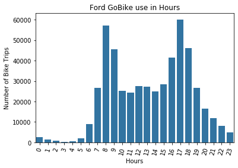

```python
# Hourly usage of the Ford Go Bike System
base_color=sb.color_palette()[0]

sb.countplot(data=df_cleaned,x='start_time_hour',color =base_color);
plt.xlabel("Hours")
plt.ylabel("Number of Bike Trips")
plt.title('Ford GoBike use in Hours')
plt.xticks(rotation=75);
```

**Observation3**

The bikes saw the most usage during the morning hours of 8-9am, and in the afternoon hours of 5-6pm.

```python
# Locations.

df_cleaned['start_station_name'].value_counts()
```

```
San Francisco Ferry Building (Harry Bridges Plaza)                 15187
The Embarcadero at Sansome St                                      13664
San Francisco Caltrain (Townsend St at 4th St)                     12546
San Francisco Caltrain Station 2  (Townsend St at 4th St)          12055
Market St at 10th St                                               11960
Montgomery St BART Station (Market St at 2nd St)                   11334
Berry St at 4th St                                                 10956
Powell St BART Station (Market St at 4th St)                       10142
Howard St at Beale St                                               9926
Steuart St at Market St                                             9347
Powell St BART Station (Market St at 5th St)                        7987
Embarcadero BART Station (Beale St at Market St)                    7649
2nd St at Townsend St - Coming Soon                                 6605
3rd St at Townsend St                                               6414
Townsend St at 7th St                                               6223
The Embarcadero at Steuart St                                       5980
2nd St at S Park St                                                 5785
Howard St at 2nd St                                                 5732
Union Square (Powell St at Post St)                                 5609
19th Street BART Station                                            5558
Civic Center/UN Plaza BART Station (Market St at McAllister St)     5497
Post St at Kearny St                                                4842
Spear St at Folsom St                                               4798
S Van Ness Ave at Market St                                         4795
The Embarcadero at Bryant St                                        4750
Mechanics Monument Plaza (Market St at Bush St)                     4656
5th St at Howard St                                                 4648
2nd St at Folsom St                                                 4600
Broadway at Kearny                                                  4511
The Embarcadero at Vallejo St                                       4269
                                                                   ...
14th St at Filbert St                                                105
Ninth St at Heinz Ave                                                 94
Fruitvale Ave at International Blvd                                   71
San Pablo Ave at 27th St                                              62
Mission St at 1st St                                                  61
13th St at Franklin St                                                61
Telegraph Ave at Carleton St                                          61
Ninth St at Parker St                                                 60
College Ave at Bryant Ave                                             59
Vine St at Shattuck Ave                                               58
Delmas Ave and San Fernando St                                        56
21st Ave at International Blvd                                        54
Dolores St at 22nd St                                                 47
26th Ave at International Blvd                                        41
Foothill Blvd at 42nd Ave                                             39
Webster St at 19th St                                                 37
Channing Way at San Pablo Ave                                         35
Willow St at Vine St                                                  30
Palm St at Willow St                                                  29
Foothill Blvd at Harrington Ave                                       28
Fruitvale BART Station                                                24
University Ave at Oxford St                                           24
Derby St at College Ave                                               16
W St John St at Guadalupe River Trail                                 15
Bestor Art Park                                                       15
Pierce Ave at Market St                                               11
Harmon St at Adeline St                                                6
Empire St at 1st St                                                    5
Jackson St at 11th St                                                  2
Ellsworth St at Russell St                                             1
Name: start_station_name, Length: 272, dtype: int64
```

```python
df_cleaned['end_station_name'].value_counts()
```

```
San Francisco Caltrain (Townsend St at 4th St)                     17378
San Francisco Ferry Building (Harry Bridges Plaza)                 17109
The Embarcadero at Sansome St                                      16531
San Francisco Caltrain Station 2  (Townsend St at 4th St)          13658
Montgomery St BART Station (Market St at 2nd St)                   13443
Market St at 10th St                                               11298
Powell St BART Station (Market St at 4th St)                       11064
Berry St at 4th St                                                 10611
Steuart St at Market St                                             9321
Powell St BART Station (Market St at 5th St)                        8563
Howard St at Beale St                                               7791
2nd St at Townsend St - Coming Soon                                 7277
Townsend St at 7th St                                               6681
Embarcadero BART Station (Beale St at Market St)                    6320
Civic Center/UN Plaza BART Station (Market St at McAllister St)     6275
3rd St at Townsend St                                               6132
The Embarcadero at Steuart St                                       5814
Howard St at 2nd St                                                 5722
Post St at Kearny St                                                5651
2nd St at S Park St                                                 5581
19th Street BART Station                                            5505
Spear St at Folsom St                                               5441
Mechanics Monument Plaza (Market St at Bush St)                     5232
5th St at Howard St                                                 5095
S Van Ness Ave at Market St                                         4574
Valencia St at 16th St                                              4472
The Embarcadero at Vallejo St                                       4381
Beale St at Harrison St                                             4289
The Embarcadero at Bryant St                                        4179
Valencia St at 24th St                                              4138
                                                                   ...
5th St at Taylor St                                                  103
Marston Campbell Park                                                 92
Fruitvale Ave at International Blvd                                   83
21st Ave at International Blvd                                        71
Ninth St at Parker St                                                 70
Mission St at 1st St                                                  65
Telegraph Ave at Carleton St                                          65
Dolores St at 22nd St                                                 63
26th Ave at International Blvd                                        61
Vine St at Shattuck Ave                                               60
College Ave at Bryant Ave                                             56
San Pablo Ave at 27th St                                              55
Channing Way at San Pablo Ave                                         49
Webster St at 19th St                                                 48
13th St at Franklin St                                                48
Delmas Ave and San Fernando St                                        48
Palm St at Willow St                                                  37
Foothill Blvd at 42nd Ave                                             36
Foothill Blvd at Harrington Ave                                       31
Fruitvale BART Station                                                30
University Ave at Oxford St                                           29
Willow St at Vine St                                                  22
W St John St at Guadalupe River Trail                                 19
Derby St at College Ave                                               18
Bestor Art Park                                                       17
Pierce Ave at Market St                                                7
Harmon St at Adeline St                                                4
Jackson St at 11th St                                                  3
Empire St at 1st St                                                    2
Ellsworth St at Russell St                                             2
Name: end_station_name, Length: 272, dtype: int64
```

```python
locs = ['San Francisco Ferry Building (Harry Bridges Plaza)','The Embarcadero at Sansome St','San Francisco Caltrain (Townsend St at 4th St)','San Francisco Caltrain Station 2  (Townsend St at 4th St)','Market St at 10th St']
df_top5 = df_cleaned.loc[df_cleaned['start_station_name'].isin(locs)]
```

```python
st_stat_order = df_top5['start_station_name'].value_counts().index
```

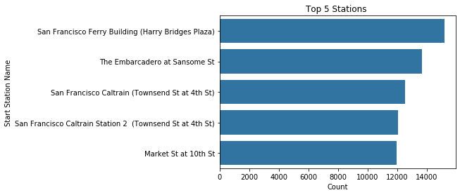

```python
base_color = sb.color_palette()[0]
sb.countplot(data=df_top5, y='start_station_name', color=base_color, order=st_stat_order)
plt.xlabel('Count')
plt.ylabel('Start Station Name')
plt.title('Top 5 Stations ');
```

**observation4**

After checking start and end stations, most stations in San Francisco connect to public transportations such as Caltrain

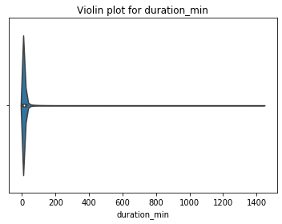

```python
#violin plot for duration minute
sb.violinplot(data = df_cleaned, x = 'duration_min');
plt.title("Violin plot for duration_min");
```

**observation5**

It's seems that most data are below 50. Let's find out the distribution.

```python
df_cleaned.duration_min.describe()
```

```
count    519700.000000
mean         18.316825
std          57.402441
min           1.016667
25%           6.366667
50%           9.933333
75%          15.633333
max        1439.483333
Name: duration_min, dtype: float64
```

# Bivariate Exploration

## No. of bikes trips by each user type

'Customer' bikers bike longer than 'Subscriber' bikers.

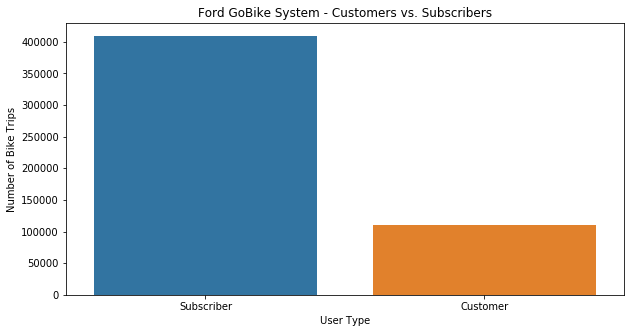

```python
# Customers vs Subscribers Visuals
# bar chart
plt.figure(figsize = [10, 5])

sb.countplot(data = df_cleaned, x = "user_type",order=df_cleaned.user_type.value_counts().index);
plt.xlabel('User Type');
plt.ylabel('Number of Bike Trips');
plt.title('Ford GoBike System - Customers vs. Subscribers');
```

**observation1**

'Customer' bikers bike longer than 'Subscriber' bikers.

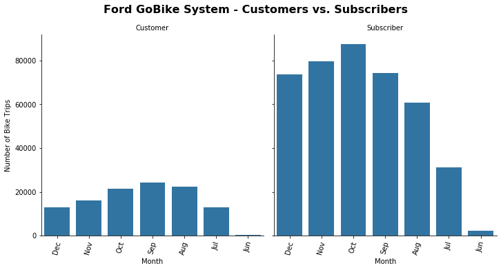

```python
#plt.figure(figsize = [12, 5])
graph = sb.catplot(data=df_cleaned, x='start_month_char', col="user_type", kind='count', sharey = True, color = base_color);

graph.set_axis_labels("Month", "Number of Bike Trips");
graph.set_titles("{col_name}");

graph.fig.suptitle('Ford GoBike System - Customers vs. Subscribers', y=1.05, fontsize=16, fontweight='bold');
graph.set_xticklabels(rotation=75);
```

**Observation2**

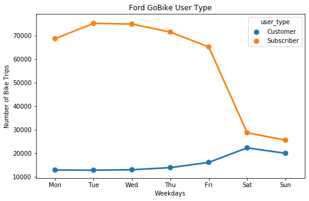

```python
plt.figure(figsize=(8, 5))

df_cleaned_user_week = df_cleaned.groupby(['start_time_weekday', 'user_type']).size().reset_index()
weekday = ['Mon', 'Tue', 'Wed', 'Thu', 'Fri', 'Sat', 'Sun']

ax = sb.pointplot(data=df_cleaned_user_week, x='start_time_weekday',y=0, hue = 'user_type', order = weekday);

plt.title('Ford GoBike User Type')
plt.xlabel('Weekdays')
plt.ylabel('Number of Bike Trips');
```

**observation3**

The point plot sharp contrast between Customers and Subscribers

# Multivariate plot

## Avg. Trip Duration in Minute in each weekday for usertype

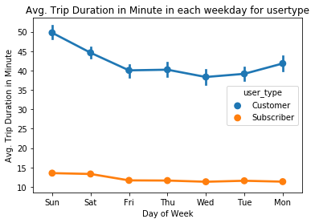

```python
sb.pointplot(data=df_cleaned, x='start_time_weekday', y='duration_min', hue='user_type');
plt.xlabel('Day of Week');
plt.ylabel('Avg. Trip Duration in Minute');
plt.title("Avg. Trip Duration in Minute in each weekday for usertype");
```

**observation1**

It can be seen from the above plot that subscribers ride much shorter/quicker trips compared to customers on each day of the week.

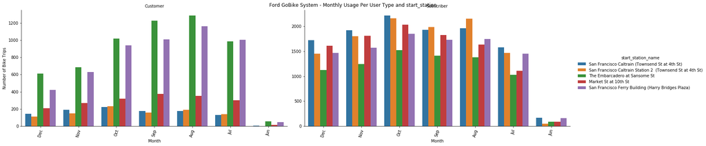

```python
plt.figure(figsize=[10,10])
graph = sb.catplot(data=df_top5, x='start_month_char', col="user_type", hue="start_station_name", kind='count', sharey = False, height=5, aspect=2);

graph.set_axis_labels("Month", "Number of Bike Trips")
graph._legend.set_title('start_station_name')
graph.set_titles("{col_name}")

graph.fig.suptitle('Ford GoBike System - Monthly Usage Per User Type and start_station');
graph.set_xticklabels(rotation=75);
```

**observation2**

After checking start and end stations, most stations in San Francisco connect to public transportations such as Caltrain

[figure not shown]

```python
fig = plt.figure(figsize = [8,6])
ax = sb.pointplot(data =df_cleaned, x = 'start_time_weekday', y = 'duration_min', hue = 'user_type',
           palette = 'Purples', linestyles = '', dodge = 0.3);
plt.title('Biking durations for bikers who are younger than 40 years old across dayofweek and user type');
plt.ylabel('Mean Duration (min)')
plt.yscale('log');
plt.yticks([1, 2, 5, 10, 20, 50, 100], [1, 2, 5, 10, 20, 50, 100]);
ax.set_yticklabels([],minor = True);
```

**observation3**

'Customer' bikers bike longer than 'Subscriber' bikers.

## Sources

.[FordGoBike Data Set](https://s3.amazonaws.com/baywheels-data/index.html)dataset

.[Matplotlib](https://matplotlib.org/)